# Effectiveness of sacubitril/valsartan versus aldosterone antagonists in heart failure with reduced ejection fraction: A retrospective cohort study - Riaz - 2021 - Pharmacotherapy: The Journal of Human

[Pharmacotherapy: The Journal of Human Pharmacology and Drug Therapy](https://accpjournals.onlinelibrary.wiley.com/journal/18759114)

[Volume 41, Issue 9](https://accpjournals.onlinelibrary.wiley.com/toc/18759114/2021/41/9) p. 710-721

ORIGINAL RESEARCH ARTICLE

Full Access

# Effectiveness of sacubitril/valsartan versus aldosterone antagonists in heart failure with reduced ejection fraction: A retrospective cohort study

[Munaza Riaz](https://accpjournals.onlinelibrary.wiley.com/action/doSearch?ContribAuthorRaw=Riaz%2C+Munaza),

[Steven M. Smith](https://accpjournals.onlinelibrary.wiley.com/action/doSearch?ContribAuthorRaw=Smith%2C+Steven+M),

[Eric A. Dietrich](https://accpjournals.onlinelibrary.wiley.com/action/doSearch?ContribAuthorRaw=Dietrich%2C+Eric+A),

[Carl J. Pepine](https://accpjournals.onlinelibrary.wiley.com/action/doSearch?ContribAuthorRaw=Pepine%2C+Carl+J),

[Haesuk Park](https://accpjournals.onlinelibrary.wiley.com/action/doSearch?ContribAuthorRaw=Park%2C+Haesuk),

First published: 25 June 2021

https://doi.org/10.1002/phar.2610

Check for Full Text

## Abstract

### Design

Retrospective cohort study.

### Data Source

IBM<sup>®</sup> MarketScan<sup>®</sup> research databases (2014–2018).

## 1 INTRODUCTION

In the United States (US), 6.2 million adults have heart failure (HF), and more than a million HF-related hospitalizations occur annually. Half of these hospitalizations are due to HF with reduced ejection fraction (HFrEF).<sup>1</sup> Despite significant advances in HF management, morbidity and mortality remain high. Angiotensin-converting enzyme inhibitors (ACEIs) and β-blockers have been the cornerstone of treatment for HF since they were shown to reduce mortality in patients with HFrEF.<sup>2, 3</sup> In 2015, sacubitril/valsartan (SAC/VAL), a first-in-class angiotensin receptor-neprilysin inhibitor, was approved by the US Food and Drug Administration for management of HFrEF. Evidence from multicenter randomized clinical trials (RCTs) has shown superior efficacy of SAC/VAL in lowering risks of mortality and HF-related hospitalization compared with the ACEI enalapril.<sup>4, 5</sup> Most importantly, PARADIGM-HF has shown that patients receiving SAC/VAL have 20% lower risk of cardiovascular death or HF-related hospitalization than those receiving enalapril.<sup>4</sup>

Aldosterone antagonists (ARAs) are also recommended for HFrEF given that aldosterone plays a vital part in the pathophysiology of HF by promoting myocardial fibrosis and decreasing norepinephrine reuptake in addition to its electrolyte and metabolic effects.<sup>6</sup> Several RCTs have demonstrated the efficacy of ARAs when added to standard therapy (ie, ACEI/ARB, diuretic, and β-blocker) to reduce mortality and HF-related hospitalization among patients with HFrEF.<sup>7, 8</sup> A subsequent meta-analysis of RCTs determined that additional use of an ARA with an ACEI/ARB and a β-blocker combined reduces re-hospitalization due to HF or cardiac causes among patients with mild-to-moderate HFrEF.<sup>9</sup> Observational studies have also found a protective effect of ARA use on the risk of HF-related readmissions among older patients with HFrEF.<sup>9, 10</sup>

SAC/VAL and ARA were each recommended Step 2 therapies by American Heart Association 2017 guidelines during a portion of the time period analyzed in this study.<sup>11</sup> Recently, SAC/VAL has been recommended as first-line therapy for patients with HFrEF by the 2021 report of the American College of Cardiology (ACC) Solution Set Oversight Committee even for those who are already on ACEI or ARB.<sup>12</sup> However, the question whether ARA should be added prior to SAC/VAL initiation or not still remains unanswered because of little data on order of initiation. To date, there are no direct comparisons of SAC/VAL and ARAs. Thus, we aimed to assess the effectiveness of SAC/VAL versus ARA therapy for prevention of HF-related hospitalization and all-cause hospitalization in a large cohort of patients with HFrEF.

## 2 METHODS

### 2.1 Study design and data source

We conducted a retrospective cohort study using IBM<sup>®</sup> MarketScan<sup>®</sup> research databases, from January 1, 2014, to December 31, 2018. The databases contain de-identified patient-level medical and pharmacy claims data of nearly 70 million individuals annually. Data are contributed by large employers, managed care organizations, hospitals, electronic medical records providers, and Medicare. The commercial and Medicare supplemental databases contain the healthcare experience of individuals in the United States with primary or Medicare supplemental coverage through privately insured fee-for-service, point-of-service, or capitated health plans. This study was approved by the University of Florida Institutional Review Board.

### 2.2 Study population

Patients aged ≥18 years were included on their first HFrEF hospital admission on or after January 1, 2015, with a primary or secondary diagnosis of HFrEF in inpatient admission claims, and if they had no other HF-related hospital admission in the preceding 12 months. *International Classification of Diseases*, *Ninth Revision*, *Clinical Modification* (*ICD*-*9*-*CM*) codes (428.2x) and *ICD*-*10*-*CM* (I50.2x) codes,<sup>13, 14</sup> were used to identify HFrEF. Patients were required to be new users of an ARA (spironolactone or eplerenone) or SAC/VAL within 180 days of the hospital discharge date of the first HFrEF admission. They were also required to have continuous enrollment in their health plan for the 12 months prior to HFrEF admission and through treatment initiation. The treatment initiation date of SAC/VAL or ARA was considered the index date (Figure S1).

### 2.3 Study outcomes

The primary study outcome was an HF-related hospital readmission, defined as a primary hospital discharge diagnosis for HF, using the previously validated *ICD*-*9*-*CM* codes 402.x1, 404.x1, 404.x3, and 428.xx and *ICD*-*10*-*CM* codes I11.0, I13.0, I13.2, I50.1, I50.2, I50.3, I50.4, and I50.9 with positive predictive values (PPVs) in the range of 80%–97%.<sup>15, 16</sup> The secondary outcome was all-cause hospitalization. Patient follow-up occurred, separately for HF-related and all-cause hospitalization, from the index date to first occurrence of an outcome, treatment discontinuation (>30-day gap between prescription refills after expiration of the last prescription's supply), switch to the study comparator, end of continuous enrollment in the health plan, or end of the study period (ie, December 31, 2018).

### 2.4 Adjustment for confounders

To adjust for differences in baseline characteristics and disease risk factors, one SAC/VAL user was matched with up to 3 ARA users based on propensity score (PS) matched (1 up to 3) using the nearest neighbor method (0.05 caliper). Logistic regression was used to estimate the probability of initiating SAC/VAL or an ARA, conditional on baseline covariates during the year prior to the index date. The covariates considered were demographic variables (age, sex, type of benefit plan, and region of residence), and medical conditions reported in the literature as being associated with HF-related hospitalization (diabetes, hypertension, cerebrovascular disease, chronic obstructive pulmonary disease, dyslipidemia, coronary artery disease [CAD], chronic kidney disease [CKD] stages 3–5, anemia, peripheral vascular disease, heart valve disease, myocardial infarction [MI], depression, arrhythmias, hypotension and hypokalemia), oxygen use, and medications (ARB, ACEI, β-blocker, and loop diuretic). Medical conditions were captured by identifying patients with at least one relevant inpatient *ICD*-*9*-*CM* or *ICD*-*10*-*CM* code (complete code list can be found in Appendix S1). Medication use was measured using national drug codes between the first HFrEF hospital discharge and the index date on which SAC/VAL or an ARA was started. Time to initiation of SAC/VAL or ARA (from hospital discharge) measured in weeks, as well as total follow-up days, number of prior HF events, and all-cause healthcare setting visits prior to and including the index date were also used to calculate the PS. In addition to matching on PS, patients were exact matched on sex.

### 2.5 Statistical analysis

Differences in baseline characteristics between SAC/VAL and ARA initiators were assessed with standardized differences (<0.1 absolute value considered well balanced). Rates of HF-related and all-cause readmissions were calculated as the number of events per 100 person-years and compared using multivariable Cox proportional hazards models. After 1 up to 3 PS matching, we also adjusted for the aforementioned covariates in the regression models, except for region of residence, type of benefit plan, and number of follow-up days. To account for clustering within matched sets, we used robust variance estimates. The proportionality assumption was assessed by review of Schoenfeld residuals and was found to be valid. We calculated and reported the *E*-value<sup>18, 19</sup> to indicate the minimum strength of association that an unmeasured confounding factor would need to have with the treatment and outcome to explain away an association between treatment and hospitalizations.

We conducted several subgroup analyses, including age categories, sex, and selected comorbidities (diabetes, hypertension, CAD, CKD, MI, prior use of ACEI/ARB, and prior HF inpatient visit between first HFrEF discharge and index date). We also performed analyses on subgroups of patients using ACEI/ARB plus ARA and those who initiated treatment at least 6 weeks after hospital discharge. Patients were rematched within each subgroup for the analyses. Subgroup analyses, conducted in each subgroup, were equated to separate analyses and tested for interaction terms in a single regression model that included both groups. The P-value of the interaction term was reported (*p*<sub>interaction</sub>). A *p*<sub>interaction</sub> value <0.05 was considered statistically significant. Sensitivity analyses were performed to examine the potential heterogeneity of treatment effects in time to initiation of SAC/VAL or ARA from first hospital discharge (6, 12, 18, and 24 weeks). All analyses were conducted using SAS, version 9.4 (SAS Institute Inc.; Cary, North Carolina).

## 3 RESULTS

### 3.1 Patient characteristics

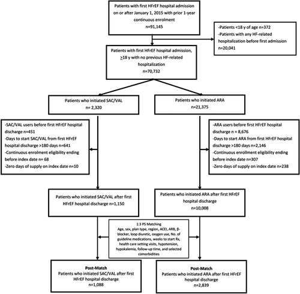

**FIGURE 1**

Study cohort flow diagram. ACEI, angiotensin-converting enzyme inhibitor; ARA, aldosterone antagonist; ARB, angiotensin receptor blocker; HFrEF, heart failure with reduced ejection fraction; PS, propensity score; Rx, prescription; SAC/VAL, sacubitril/valsartan

TABLE 1. Demographics and clinical characteristics of patients with heart failure with reduced ejection fraction

[output not shown]

- Abbreviations: ACEI, angiotensin-converting enzyme inhibitor; ARA, aldosterone antagonist; ARB, angiotensin receptor blocker; CDHP, consumer directed health plan; EPO, exclusive provider organization; HDHP, high deductible health plan; HF, heart failure; HMO, health maintenance organization; POS, point of service; PPO, preferred provider organization; Rx, prescription; SAC/VAL, sacubitril/valsartan; SD, standard deviation; Std diff, standardized difference.
- <sup>a</sup> Inpatient visits were determined between first HFrEF hospital discharge and index date (patients had no HF inpatient visit before first HFrEF hospital admission).
- <sup>b</sup> Number of recommended guideline medications includes ACEI/ARB, β-blocker, isosorbide dinitrate plus hydralazine, digoxin, and ivabradine used between index hospital discharge date and index prescription date.

### 3.2 Outcomes

The mean and standard deviation (SD) follow-up times of matched SAC/VAL and ARA groups were 335 (262) days and 341 (285) days, respectively (Table 1). We identified 98 HF-related hospitalizations in the SAC/VAL group and 317 HF-related hospitalizations in the ARA group (Table 2). The crude HF-related hospitalization rate was 13 per 100 person-years for SAC/VAL users versus 18 per 100 person-years for ARA users. Risk of HF-related hospitalization was 27% lower among SAC/VAL users compared with ARA users (adjusted HR [aHR], 0.73; 95% confidence interval [CI], 0.58–0.91; *p* = 0.006). Descriptions of HF-related hospitalization events can be found in Table S1. We calculated the *E*-value to account for the impact of unobserved confounding factors on estimated HR for hospitalization. An unmeasured confounder would need to have a minimum risk ratio of 2.08, above and beyond measured confounders, to fully explain away the association between treatment and HF-related hospitalization (Table 2).

TABLE 2. Risk of HF-related and all-cause hospitalizations with sacubitril/valsartan vs. aldosterone antagonists in propensity score-matched analyses

|  | Patients, *n* | Person-years | Events, *n* | Crude incidence per 100 person-years | Adjusted hazard ratio (95% CI)<sup>a</sup> | *p*-Value | *E*-value<sup>b</sup> |  |
| --- | --- | --- | --- | --- | --- | --- | --- | --- |
| HF-related hospitalization |  |  |  |  |  |  |  |  |
| Sacubitril/valsartan | 1088 | 784 | 98 | 13 | 0.73 (0.58–0.91) | 0.006 | Estimate = 2.08 CI = 1.43 |  |
| Aldosterone antagonist | 2839 | 1793 | 317 | 18 | Reference |  |  |  |
| All-cause hospitalization |  |  |  |  |  |  |  |  |
| Sacubitril/valsartan | 1088 | 697 | 294 | 42 | 0.69 (0.61–0.79) |  | <0.001 | Estimate = 1.91 CI = 1.63 |
| Aldosterone antagonist | 2839 | 1554 | 954 | 61 | Reference |  |  |  |

- Abbreviations: CI, confidence interval; HF, heart failure.
- <sup>a</sup> Models were adjusted for age, sex, angiotensin-converting enzyme inhibitor/angiotensin receptor blocker, β-blocker, loop diuretics, oxygen use, No. of guideline medications used, healthcare setting visits (all-cause, HF-related), follow-up days, weeks from index hospital discharge to index prescription, anemia, coronary artery disease, cerebrovascular disease, peripheral vascular disease, diastolic heart failure, dyslipidemia, chronic kidney disease, diabetes mellitus, hypertension, chronic obstructive pulmonary disease, depression, myocardial infarction, heart valve disease, arrhythmia, hypokalemia, and hypotension.
- <sup>b</sup> *E*-value was calculated and interpreted to describe minimum strength of association of an unmeasured confounder with treatment and outcome.

Among SAC/VAL users, there were 294 all-cause hospitalizations, or 42 per 100 person-years, compared with 954 all-cause hospitalizations, or 61 per 100 person-years, among ARA users. SAC/VAL users had a 31% lower risk of all-cause hospitalization (aHR, 0.69; 95% CI, 0.61–0.79; *p* < 0.001) compared with ARA users (Table 2). Descriptions of all-cause events can be found in Table S2. The *E*-value for the aHR estimate of all-cause hospitalization was 1.91 and for CI was 1.63 (Table 2). In other words, an unmeasured confounder would need to have a minimum risk ratio of 1.91, above and beyond measured confounders, to fully explain away the association between treatment and all-cause hospitalization (Table 2).

### 3.3 Subgroup and sensitivity analyses

No statistically significant differences were observed across prespecified subgroup analyses for risk of HF-related hospitalization (Table 3) or all-cause hospitalization (Table 4). Similar results were observed in subgroups of SAC/VAL vs. ARA plus ACEI/ARB users (Table S3) and patients who initiated the treatment at least 6 weeks after hospital discharge (Table S4).

TABLE 3. Risk of heart failure-related hospitalization with sacubitril/valsartan vs. aldosterone antagonists in propensity score-matched subgroup analyses

[output not shown]

- Abbreviations: ACEI, angiotensin-converting enzyme inhibitor; ARB, angiotensin receptor blocker; CI, confidence interval.
- <sup>a</sup> Between first heart failure with reduced ejection fraction hospital discharge date and index date.

TABLE 4. Risk of all-cause hospitalization with sacubitril/valsartan vs. aldosterone antagonists in propensity score-matched subgroup analyses

|  | Patients, *n* | Person-years | Events, *n* | Crude incidence per 100 person-years | Adjusted hazard ratio (95% CI) | *p* <sub>Interaction</sub> |  |  |  |  |  |  |  |
| --- | --- | --- | --- | --- | --- | --- | --- | --- | --- | --- | --- | --- | --- |
| Age category, years |  |  |  |  |  |  |  |  |  |  |  |  |  |
| 18–44 |  |  |  |  |  | 0.09 |  |  |  |  |  |  |  |
| Sacubitril/valsartan | 96 | 61 | 19 | 31 | 0.66 (0.36–1.20) |  |  |  |  |  |  |  |  |
| Aldosterone antagonist | 223 | 137 | 54 | 39 | Reference |  |  |  |  |  |  |  |  |
| 45–64 |  |  |  |  |  |  |  |  |  |  |  |  |  |
| Sacubitril/valsartan | 582 | 381 | 122 | 32 | 0.61 (0.50–0.75) |  |  |  |  |  |  |  |  |
| Aldosterone antagonist | 1417 | 806 | 429 | 53 | Reference |  |  |  |  |  |  |  |  |
| ≥65 |  |  |  |  |  |  |  |  |  |  |  |  |  |
| Sacubitril/valsartan | 366 | 233 | 149 | 64 | 0.79 (0.66–0.96) |  |  |  |  |  |  |  |  |
| Aldosterone antagonist | 989 | 557 | 433 | 78 | Reference |  |  |  |  |  |  |  |  |
| Sex |  |  |  |  |  |  |  |  |  |  |  |  |  |
| Men |  |  |  |  |  |  | 0.54 |  |  |  |  |  |  |
| Sacubitril/valsartan | 758 | 490 | 206 | 42 | 0.68 (0.58–0.79) |  |  |  |  |  |  |  |  |
| Aldosterone antagonist | 1943 | 1042 | 657 | 63 | Reference |  |  |  |  |  |  |  |  |
| Women |  |  |  |  |  |  |  |  |  |  |  |  |  |
| Sacubitril/valsartan | 323 | 202 | 87 | 43 | 0.66 (0.51–0.86) |  |  |  |  |  |  |  |  |
| Aldosterone antagonist | 886 | 481 | 302 | 63 | Reference |  |  |  |  |  |  |  |  |
| Prior ACEI/ARB<sup>a</sup> |  |  |  |  |  |  |  |  |  |  |  |  |  |
| Present |  |  |  |  |  |  |  | 0.95 |  |  |  |  |  |
| Sacubitril/valsartan | 440 | 282 | 112 | 40 | 0.68 (0.55–0.84) |  |  |  |  |  |  |  |  |
| Aldosterone antagonist | 1169 | 632 | 388 | 61 | Reference |  |  |  |  |  |  |  |  |
| Absent |  |  |  |  |  |  |  |  |  |  |  |  |  |
| Sacubitril/valsartan | 622 | 404 | 180 | 45 | 0.71 (0.60–0.84) |  |  |  |  |  |  |  |  |
| Aldosterone antagonist | 1604 | 922 | 551 | 60 | Reference |  |  |  |  |  |  |  |  |
| Diabetes |  |  |  |  |  |  |  |  |  |  |  |  |  |
| Present |  |  |  |  |  |  |  |  | 0.30 |  |  |  |  |
| Sacubitril/valsartan | 345 | 217 | 118 | 54 | 0.77 (0.62–0.95) |  |  |  |  |  |  |  |  |
| Aldosterone antagonist | 823 | 439 | 307 | 70 | Reference |  |  |  |  |  |  |  |  |
| Absent |  |  |  |  |  |  |  |  |  |  |  |  |  |
| Sacubitril/valsartan | 723 | 471 | 173 | 37 | 0.66 (0.56–0.79) |  |  |  |  |  |  |  |  |
| Aldosterone antagonist | 1854 | 1017 | 568 | 56 | Reference |  |  |  |  |  |  |  |  |
| Hypertension |  |  |  |  |  |  |  |  |  |  |  |  |  |
| Present |  |  |  |  |  |  |  |  |  | 0.17 |  |  |  |
| Sacubitril/valsartan | 543 | 363 | 166 | 46 | 0.78 (0.65–0.93) |  |  |  |  |  |  |  |  |
| Aldosterone antagonist | 1449 | 853 | 482 | 56 | Reference |  |  |  |  |  |  |  |  |
| Absent |  |  |  |  |  |  |  |  |  |  |  |  |  |
| Sacubitril/valsartan | 528 | 322 | 128 | 40 | 0.64 (0.53–0.78) |  |  |  |  |  |  |  |  |
| Aldosterone antagonist | 1334 | 668 | 425 | 64 | Reference |  |  |  |  |  |  |  |  |
| Chronic kidney disease |  |  |  |  |  |  |  |  |  |  |  |  |  |
| Present |  |  |  |  |  |  |  |  |  |  | 0.28 |  |  |
| Sacubitril/valsartan | 258 | 153 | 74 | 49 | 0.59 (0.46–0.76) |  |  |  |  |  |  |  |  |
| Aldosterone antagonist | 666 | 318 | 250 | 79 | Reference |  |  |  |  |  |  |  |  |
| Absent |  |  |  |  |  |  |  |  |  |  |  |  |  |
| Sacubitril/valsartan | 803 | 536 | 209 | 39 | 0.70 (0.60–0.81) |  |  |  |  |  |  |  |  |
| Aldosterone antagonist | 2075 | 1245 | 695 | 56 | Reference |  |  |  |  |  |  |  |  |
| Coronary artery disease |  |  |  |  |  |  |  |  |  |  |  |  |  |
| Present |  |  |  |  |  |  |  |  |  |  |  | 0.07 |  |
| Sacubitril/valsartan | 521 | 319 | 167 | 52 | 0.81 (0.67–0.96) |  |  |  |  |  |  |  |  |
| Aldosterone antagonist | 1355 | 759 | 476 | 63 | Reference |  |  |  |  |  |  |  |  |
| Absent |  |  |  |  |  |  |  |  |  |  |  |  |  |
| Sacubitril/valsartan | 542 | 362 | 119 | 33 | 0.60 (0.50–0.73) |  |  |  |  |  |  |  |  |
| Aldosterone antagonist | 1409 | 781 | 434 | 56 | Reference |  |  |  |  |  |  |  |  |
| Prior inpatient visit for heart failure<sup>a</sup> |  |  |  |  |  |  |  |  |  |  |  |  |  |
| Yes |  |  |  |  |  |  | 0.86 |  |  |  |  |  |  |
| Sacubitril/valsartan | 43 | 23 | 16 | 69 | 0.53 (0.22–1.27) |  |  |  |  |  |  |  |  |
| Aldosterone antagonist | 105 | 54 | 48 | 88 | Reference |  |  |  |  |  |  |  |  |
| No |  |  |  |  |  |  |  |  |  |  |  |  |  |
| Sacubitril/valsartan | 1043 | 673 | 276 | 41 | 0.66 (0.58–0.75) |  |  |  |  |  |  |  |  |
| Aldosterone antagonist | 2674 | 1473 | 898 | 61 | Reference |  |  |  |  |  |  |  |  |
| Myocardial infarction |  |  |  |  |  |  |  |  |  |  |  |  |  |
| Present |  |  |  |  |  |  |  |  |  |  |  |  | 0.19 |
| Sacubitril/valsartan | 209 | 134 | 65 | 48 | 0.78 (0.60–1.01) |  |  |  |  |  |  |  |  |
| Aldosterone antagonist | 539 | 303 | 187 | 62 | Reference |  |  |  |  |  |  |  |  |
| Absent |  |  |  |  |  |  |  |  |  |  |  |  |  |
| Sacubitril/valsartan | 856 | 547 | 224 | 41 | 0.65 (0.56–0.75) |  |  |  |  |  |  |  |  |
| Aldosterone antagonist | 2258 | 1233 | 773 | 63 | Reference |  |  |  |  |  |  |  |  |

- Abbreviations: ACEI, angiotensin-converting enzyme inhibitor; ARB, angiotensin receptor blocker; CI, confidence interval.
- <sup>a</sup> Between first heart failure with reduced ejection fraction hospital discharge date and index date.

Study results remained unchanged in sensitivity analyses, including restriction to patients who started study medications within 6, 12, 18, or 24 weeks after the first HFrEF hospital discharge date (Table S5).

## 4 DISCUSSION

To the best of our knowledge, this study reports the first real-world evaluation of the comparative effectiveness of SAC/VAL and ARAs, both recommended therapies for HFrEF, in preventing the risk of HF-related or all-cause readmissions. In this retrospective cohort study of nearly 4000 PS-matched patients with HFrEF, we found that compared with using an ARA, using SAC/VAL was associated with significantly lower risk of HF-related readmission and all-cause hospitalization (Figure 2). Our subgroup analyses, which included baseline CKD, CAD, diabetes, and prior use of an ACEI or ARB, provided no evidence that the reduction in hospitalizations associated with SAC/VAL use varied among the evaluated patient subpopulations, even among those at increased risk of hospitalization.

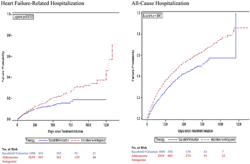

**FIGURE 2**

Risk of outcomes in patients treated with sacubitril/valsartan or aldosterone antagonist for heart failure with reduced ejection fraction

In the PARADIGM-HF and PIONEER-HF trials, SAC/VAL decreased HF-related morbidity and cardiovascular mortality compared with enalapril among those who were using ACEI, beta-blocker, and/or ARAs.<sup>5, 20</sup> Two observational studies using administrative claims databases evaluated the effectiveness of SAC/VAL compared with ARB/ACEI and found superior effects of SAC/VAL in reducing morbidity and mortality.<sup>15, 21</sup> Another study indirectly compared SAC/VAL and ARA using data for primary endpoint from PARADIGM-HF and suggested beneficial effect of SAC/VAL over enalapril plus ARA.<sup>22</sup> More recently, the TRANSITION trial suggested that the use of SAC/VAL could be initiated early prior to or shortly after HF discharge.<sup>23</sup> Consequently, the 2021 update of the ACC expert consensus decision pathway of HF treatment recommends initiation of SAC/VAL or ACEI/ARB as a first-line therapy, though SAC/VAL is the preferred agent.<sup>12</sup>

We believe our study is a valuable addition to existing literature for clinicians who have patients already on ACEI/ARB plus β-blocker and are weighing the decision to initiate or switch to SAC/VAL or the addition of ARAs with considerations to dosing, cost, and/or hemodynamic instability at baseline, or in patients where it is not likely both agents could be tolerated if co-administered. Although Escobar et al reported that using SAC/VAL was potentially associated with decreased risk of cardiovascular death compared with the use of enalapril with ARAs, the findings are limited due to differences in baseline clinical profile between the two groups, indirect comparisons from clinical trial data, which was designed for comparisons of SAC/VAL and enalapril regardless the use of ARAs.<sup>22</sup> Our study compared the two groups directly after PS matching which included their baseline clinical characteristics, healthcare utilization, and use of ACEI, ARB, B-blockers, and diuretics.

ARAs can be added to HF therapy for patients whose creatinine clearance is >30 ml/min and potassium <5.0 mEq/L. As a combination agent, SAC/VAL inhibits the renin-angiotensin-aldosterone system (RAAS) as well as neprilysin, leading to an elevation in the level of beneficial proteins in the natriuretic peptide (NP) system [ie, arterial (ANP), B-type (BNP), and C-type (CNP)]. Those proteins lead to induction of diuresis and natriuresis, inhibition of RAAS and the sympathetic nervous system, and to antifibrotic, antithrombotic, and antiproliferative effects.<sup>24</sup> ARAs are added to ACEIARB and β-blockers<sup>11</sup> to antagonize the effects of activated neurohormonal systems, such as RAAS.<sup>25</sup> The combination of systems inhibited by SAC/VAL provides greater clinical benefit than inhibition of only one system and may explain the greater reduction in hospitalization observed for the SAC/VAL users in our study.

There are several clinical implications of the results reported here. Our findings provide evidence to support current guidance<sup>12, 22</sup> that SAC/VAL is a preferred agent for reducing risk of HF-related and all-cause hospitalizations in patients with HFrEF regardless of prior use of ACEI/ARB, and with or without CAD or CKD. Thus, this study provides evidence for making decisions regarding next step therapy for patients already on ACEI/ARB. Although our findings suggested that SAC/VAL was more effective than ARAs for treatment of patients with HFrEF to prevent HF-related and all-cause readmissions, other factors (eg, drug costs,<sup>26</sup> renal function, baseline blood pressure, regular monitoring, history of angioedema, and adverse events) also need to be considered. In addition, our findings do not preclude the potential value of using SAC/VAL and ARA together, SAC/VAL and an SGLT2 inhibitor, or SAC/VAL in combination with ARA and SGLT2 as suggested by recent update,<sup>12</sup> although there could be certain patients who are only able to take one of these agents for a variety of reasons such as cost, blood glucose, blood pressure, and serum potassium.

Our study has several important strengths. First, we incorporated subgroup analyses, including MI, CKD, and CAD, that were not reported in the PARADIGM-HF trial. Second, this study used PS matching to control for imbalances between treatment groups, a study design that included only new users of the study drugs, and Cox proportional hazards models for analysis of matched groups, a doubly robust analysis, which is a relatively robust method for estimating treatment effects compared with matching or regression alone. Third, we included only patients who had an initial hospital admission with HFrEF and no HF-related hospitalization in the prior year as a proxy to minimize confounding by disease severity. We reported E-value to provide evidence of robustness of our findings to potential unmeasured confounding. Fourth, this study used a large commercial database representative of the US population covered under employer-based medical insurance. Finally, the large sample size allowed us to conduct several subgroup and sensitivity analyses to assess the robustness of the results.

Nevertheless, this study also has some limitations. We did not have information on echocardiogram or ejection fraction test results or laboratory results (eg, B-type natriuretic peptide, N-terminal pro-B-type natriuretic peptide, or cardiac enzyme levels) to corroborate ICD codes for HFrEF diagnosis, and residual confounding may exist because of this missing information. However, we reported E-value results to show that our findings were less likely to be affected by unmeasured confounders. We attempted to minimize the misclassification bias risk by using validated ICD code algorithms for HFrEF identification. This study also lacked information on race and ethnicity, precluding analyses of these subgroups. The pathophysiology of HF may vary among racial/ethnic groups, potentially explaining why some treatments may be superior to others.<sup>14</sup> Because we used an administrative claims database for prescription fills, we could not be sure that patients actually consumed the prescribed medications. But the proportion of patients who refilled their prescription was high, suggesting that patients had consumed the medication. Although we observed associations with HF-related and all-cause hospitalizations, it was not possible to assess mortality, an important outcome in HF, because comprehensive death information was not available in our dataset. Further study is required to determine whether the observed results for hospitalizations hold true for mortality. The patients included in this study had private and Medicare Advantage plans; thus, our findings may not be generalizable to patients with other health insurance plans or to patients without insurance. Patients included in the study had no HF hospitalizations in the year prior to entry in the cohort, which may represent a comparatively stable population. To mitigate this weakness, we provided a subgroup analysis of patients who had multiple hospitalizations between first HFrEF admission and therapy initiation. Although we could not completely avoid the impact of confounding by indication or severity because prescribing practices may have varied, we used PS matching to reduce confounding. However, PS matching helps control for only observed variables; bias related to latent or unmeasured variables may persist even after matching. Additionally, E-value was reported to show that unmeasured confounders did not have such association with the outcome to move the estimated effects in any other direction. A limitation of generalizability in the ARA group could have been introduced by exclusion of large number of patients in the ARA group as they were not matched with patients in the SAC/VAL group.

## 5 CONCLUSIONS

Our study findings indicated that in patients with HFrEF, compared with ARA therapy, treatment with SAC/VAL was associated with decreased HF-related hospitalization and all-cause hospitalization. The decreased hospitalization with SAC/VAL use extended to selected subgroups that were evaluated in the present study but that were not assessed in the original clinical trial, including patients with CKD or CAD. To reduce pill burden and improve clinical outcomes, switching to SAC/VAL before adding ARA can be a viable option for patients, already on ACEI/ARBs, having commercial insurance coverage.

## CONFLICT OF INTEREST

The authors declare no conflicts of interest.

[figure not shown]

September 2021

Pages 710-721

### Recommended

back